# Customer Segmentation - Clustering

## Plan

### Lifecycle

[figure not shown]

### Business Model Canvas

[figure not shown]

### Use case

We want to perform a customer segmentation.

To do this, we want to divide the customers into individual equal segments according to characteristics that are relevant for the purchase.

These segments contain similar customer groups, which we can then separate.

This helps our company to adapt our products and marketing measures to these groups and thus to motivate customers to buy and to generate loyal customers.

### Problem

We want to segment our customers to target our products and marketing more effectively in order to increase purchases und revenue.

[Source](https://www.paypal.com/us/brc/article/enterprise-solutions-tranform-digital-commerce-with-adaptive-risk-mgmt)

### Relevant metrics

In this unsupervised, there are no explicit metrics against which the accuracy of the model can be measured, beacuse there is no truth label given with the feature vector.

However, we want a number of clusters that is logically meaningful and interpretable.

We will therefore follow the elbow method and try different values and then decide which ones make more sense with our problem in mind.

## Data

```python
import numpy as np
import pandas as pd
import matplotlib.pyplot as plt
import seaborn as sns
from sklearn.cluster import KMeans
import matplotlib.cm as cm

from sklearn.preprocessing import LabelEncoder
from sklearn.metrics import silhouette_samples, silhouette_score
```

Read in our dataset using pandas and check the first 10 entries

```python
df = pd.read_csv('customers.csv')
df.head(10)
```

|  | customer_id | gender | age | income | spending_score |
| --- | --- | --- | --- | --- | --- |
| 0 | 1 | Male | 19 | 15 | 39 |
| 1 | 2 | Male | 21 | 15 | 81 |
| 2 | 3 | Female | 20 | 16 | 6 |
| 3 | 4 | Female | 23 | 16 | 77 |
| 4 | 5 | Female | 31 | 17 | 40 |
| 5 | 6 | Female | 22 | 17 | 76 |
| 6 | 7 | Female | 35 | 18 | 6 |
| 7 | 8 | Female | 23 | 18 | 94 |
| 8 | 9 | Male | 64 | 19 | 3 |
| 9 | 10 | Female | 30 | 19 | 72 |

### Analysing the data

We will not use the customer_id feature it is not useful for the model

```python
df.drop("customer_id", axis=1, inplace=True)
```

Check for null values

```python
df.isna().sum()
```

[output not shown]

[figure not shown]

```python
sns.pairplot(df,hue='gender')
plt.show()
```

We can see that the data show a good distribution at first glance.

The feature gender does not seem to have a significant influence on the distribution of the variables.

Furthermore, we can already see that annual income and spending score have an influence on each other and already form clusters.

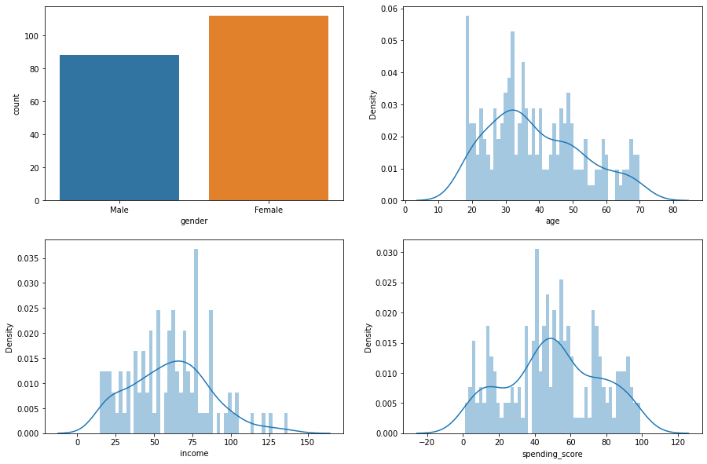

```python
fig, ax = plt.subplots(nrows=2,ncols=2,figsize=(15,10))
sns.countplot(x=df['gender'],ax = ax[0,0],)
sns.distplot(df['age'],bins=50,ax=ax[0,1])
sns.distplot(df['income'],bins=50,ax=ax[1,0])
sns.distplot(df['spending_score'],bins=50,ax=ax[1,1])
plt.show()
```

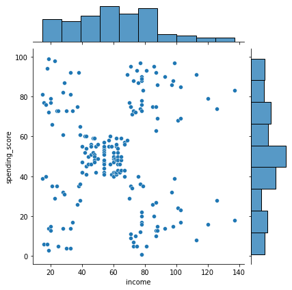

```python
sns.jointplot(df['income'],df["spending_score"])
```

We see here the density distribution of spending score and annual income, which is centered.

In addition, we see here already indicated 5 clusters - perhaps this is a good value for k.

### Feature Encoding

To check for a correlation between the features, we binarize the label gender with the label encoder.

```python
label_encoder = LabelEncoder()
df['gender_bin']  = label_encoder.fit_transform(df.gender)
```

After that, we can create a heatmap of the correlations.

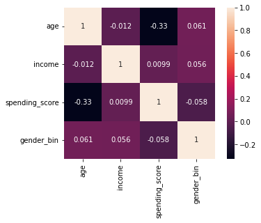

```python
sns.heatmap(df.corr(), cbar=True, square= True, annot=True)
```

There is a negative correlation between age and spending score.

Other than this, there are no other noticeable correlations.

## Model

The analysis of the data showed that income and spending score are the most suitable for clustering.

We therefore use these features to create a model with the K-means algorithm.

```python
X = df[['income','spending_score']]
```

[output not shown]

200 rows × 2 columns

To find an optimal number of clusters, we use the elbow method.

Where the "elbow" flattens out, the best number of clusters can be read.

[output not shown]

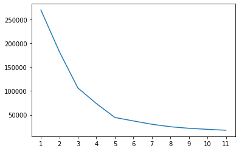

```python
from sklearn.cluster import KMeans
inertia = []
for i in range(1,12):
    k_means = KMeans(n_clusters=i, random_state=34, init='k-means++')
    k_means.fit(X)
    inertia.append(k_means.inertia_)
plt.plot(range(1,12), inertia)
plt.xticks(range(1,12))
```

The coherence of the clusters is measured with the value inertia, which is used to determine the quality of the clusters.

We see that 5 is indeed a good value to get the best ratio between the number of clusters and the inertia measure.

We now create a clustering based on the findings of the elbow method and additionally with the next two values, the 5 clusters from the elbow method and 4 and 6 for validation.

```python
k_means_4 = KMeans(n_clusters=4,init='k-means++',n_init=14,max_iter=400,random_state=29)
k_means_5 = KMeans(n_clusters=5,init='k-means++',n_init=4,max_iter=400,random_state=36)
k_means_6 = KMeans(n_clusters=6,init='k-means++',n_init=7,max_iter=400,random_state=15)
```

We cluster the data with the individual models (classify each feature vector from the dataset)

```python
y_k_means_4 = k_means_4.fit_predict(X)
df_4 = df
df_4['y_k_means_4'] = y_k_means_4
y_k_means_5 = k_means_5.fit_predict(X)
df_5 = df
df_5['y_k_means_5'] = y_k_means_5
y_k_means_6 = k_means_6.fit_predict(X)
df_6 = df
df_6['y_k_means_6'] = y_k_means_6
```

We visualize the resulting clusters in a scatterplot

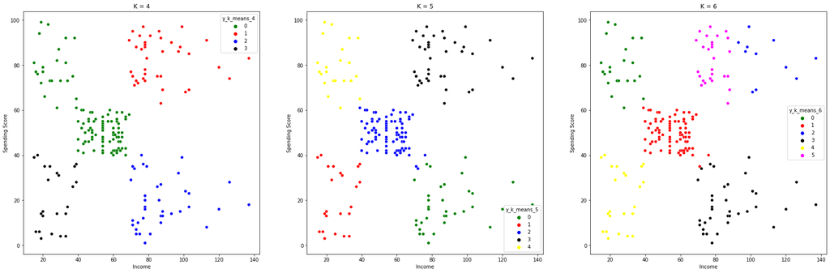

```python
fig, ax = plt.subplots(1,3,figsize=(29,9))

sns.scatterplot(x='income', y='spending_score', data=df, hue='y_k_means_4', palette=['green','red','blue','black'], ax=ax[0])
ax[0].set_title('K = 4')
ax[0].set_xlabel('Income')
ax[0].set_ylabel('Spending Score')

sns.scatterplot(x='income', y='spending_score', data=df, hue='y_k_means_5', palette=['green','red','blue','black','yellow'], ax=ax[1])
ax[1].set_title('K = 5')
ax[1].set_xlabel('Income')
ax[1].set_ylabel('Spending Score')


sns.scatterplot(x='income', y='spending_score', data=df, hue='y_k_means_6', palette=['green','red','blue','black','yellow','magenta'], ax=ax[2])
ax[2].set_title('K = 6')
ax[2].set_xlabel('Income')
ax[2].set_ylabel('Spending Score')

plt.show()
```

We see that for k = 4 we neglect the cluster in the upper left corner.

At k = 6, a cluster is created that alienates another cluster, which is not good for the validity of the model.

K = 5 seems to be the best value for the model.

```python
silhouette_avg = silhouette_score(X, y_k_means_5)
# Compute the silhouette scores for each sample
sample_silhouette_values = silhouette_samples(x, y_k_means_5)
```

[output not shown]

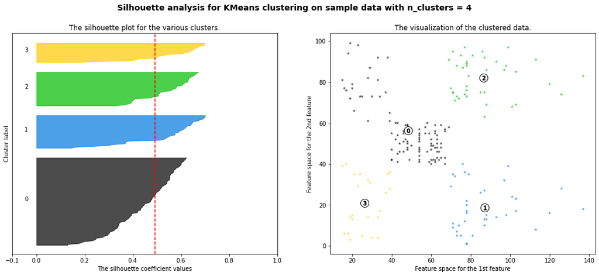

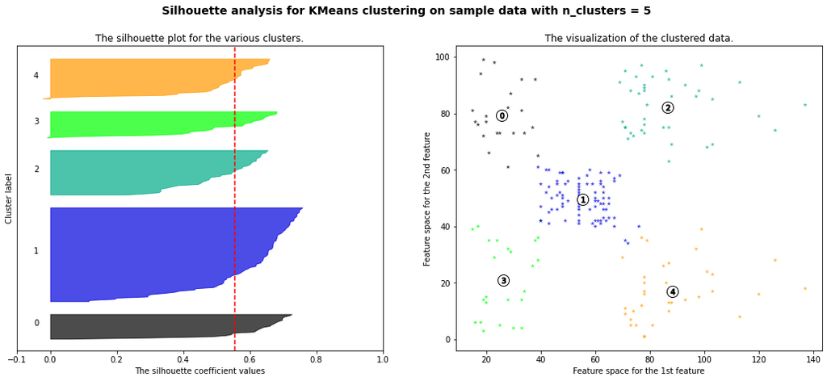

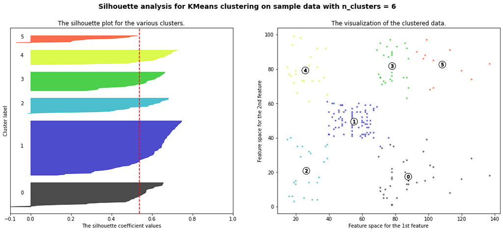

```python
range_n_clusters = [4, 5, 6]

for n_clusters in range_n_clusters:
    # Create a subplot with 1 row and 2 columns
    fig, (ax1, ax2) = plt.subplots(1, 2)
    fig.set_size_inches(18, 7)

    # The 1st subplot is the silhouette plot
    # The silhouette coefficient can range from -1, 1 but in this example all
    # lie within [-0.1, 1]
    ax1.set_xlim([-0.1, 1])
    # The (n_clusters+1)*10 is for inserting blank space between silhouette
    # plots of individual clusters, to demarcate them clearly.
    ax1.set_ylim([0, len(X) + (n_clusters + 1) * 10])

    # Initialize the clusterer with n_clusters value and a random generator
    # seed of 10 for reproducibility.
    clusterer = KMeans(n_clusters=n_clusters, random_state=10)
    cluster_labels = clusterer.fit_predict(X)

    # The silhouette_score gives the average value for all the samples.
    # This gives a perspective into the density and separation of the formed
    # clusters
    silhouette_avg = silhouette_score(X, cluster_labels)
    print(
        "For n_clusters =",
        n_clusters,
        "The average silhouette_score is :",
        silhouette_avg,
    )

    # Compute the silhouette scores for each sample
    sample_silhouette_values = silhouette_samples(X, cluster_labels)

    y_lower = 10
    for i in range(n_clusters):
        # Aggregate the silhouette scores for samples belonging to
        # cluster i, and sort them
        ith_cluster_silhouette_values = sample_silhouette_values[cluster_labels == i]

        ith_cluster_silhouette_values.sort()

        size_cluster_i = ith_cluster_silhouette_values.shape[0]
        y_upper = y_lower + size_cluster_i

        color = cm.nipy_spectral(float(i) / n_clusters)
        ax1.fill_betweenx(
            np.arange(y_lower, y_upper),
            0,
            ith_cluster_silhouette_values,
            facecolor=color,
            edgecolor=color,
            alpha=0.7,
        )

        # Label the silhouette plots with their cluster numbers at the middle
        ax1.text(-0.05, y_lower + 0.5 * size_cluster_i, str(i))

        # Compute the new y_lower for next plot
        y_lower = y_upper + 10  # 10 for the 0 samples

    ax1.set_title("The silhouette plot for the various clusters.")
    ax1.set_xlabel("The silhouette coefficient values")
    ax1.set_ylabel("Cluster label")

    # The vertical line for average silhouette score of all the values
    ax1.axvline(x=silhouette_avg, color="red", linestyle="--")

    ax1.set_yticks([])  # Clear the yaxis labels / ticks
    ax1.set_xticks([-0.1, 0, 0.2, 0.4, 0.6, 0.8, 1])

    # 2nd Plot showing the actual clusters formed
    colors = cm.nipy_spectral(cluster_labels.astype(float) / n_clusters)
    ax2.scatter(X.iloc[:, 0], X.iloc[:, 1], marker='*', s=30, lw=0, alpha=0.7,
                c=colors, edgecolor='k')

    # Labeling the clusters
    centers = clusterer.cluster_centers_
    # Draw white circles at cluster centers
    ax2.scatter(
        centers[:, 0],
        centers[:, 1],
        marker="o",
        c="white",
        alpha=1,
        s=200,
        edgecolor="k",
    )

    for i, c in enumerate(centers):
        ax2.scatter(c[0], c[1], marker="$%d$" % i, alpha=1, s=50, edgecolor="k")

    ax2.set_title("The visualization of the clustered data.")
    ax2.set_xlabel("Feature space for the 1st feature")
    ax2.set_ylabel("Feature space for the 2nd feature")

    plt.suptitle(
        "Silhouette analysis for KMeans clustering on sample data with n_clusters = %d"
        % n_clusters,
        fontsize=14,
        fontweight="bold",
    )

plt.show()
```

We see with k = 6 that the red cluster number 5 has a low score and overlaps with the green cluster 3. 6 is therefore not a good value for k.

At k= 4 we see that clusters 1 to 3 have a good score, but cluster 0 is much wider compared to the other clusters. the width represents the size of the cluster, we aim to have clusters of equal size in the optimal case.

It has been confirmed that k = 5 is the best way to separate the customers.

We are now able to divide our customers into 5 different categories and ready to deploy the model in production.